# DO3 - Introduction

2025-01-09

## Présentation du cours

## Enseignants

- Paul Bastide
  - paul.bastide@umontpellier.fr
  - Statistiques appliquées, Évolution
- Chloé Serre-Combe
  - chloe.serre-combe@umontpellier.fr
  - Statistique des extrêmes, statistique spatiale
- Alexandre Capel
  - alexandre.capel@umontpellier.fr
  - Statistique des extrêmes, modèles graphiques

## Plan du cours

**Séance 1.** (1h30) Introduction à la statistique et `R`.

**Séance 2.** (1h30) Communication de résultats.

**Séance 3.** (1h30) Gestion et formatage de tableaux de données sous `R`.

**Séance 4.** (1h30) Données qualitatives.

**Séance 5.** (1h30) Données quantitatives.

**Séance 6.** (1h30) Personnalisation de graphique.

**Séance 7.** (3h) Modèles.

**Séance 8.** (3h) `R` Shiny.

## Modalité d’évaluation

**1** “petit” TP **ET** un gros TP/projet (à définir)

- le premier sera à faire entre la séance 3 et la séance 4 à rendre sur le Moodle.
- le second sera à faire tout le long du semestre à partir de la séance 4.

## Sources de données

- [Open Data Montpellier Méditerranée Métropole](https://data.montpellier3m.fr/datasets)
- [data.gouv.fr](https://www.data.gouv.fr/fr/), avec son [compte Twitter](https://twitter.com/datagouvfr)
- [data.europa.eu](https://data.europa.eu/euodp/en/home) et le [European Data Portal](https://www.europeandataportal.eu/en)
- data.sncf.com
- [Tidy Tuesday](https://github.com/rfordatascience/tidytuesday#datasets), sur Twitter [#tidytuesday](https://twitter.com/search?q=%23tidytuesday)
- [Five Thirty Eight](https://data.fivethirtyeight.com/) et sa [librairie](https://CRAN.R-project.org/package=fivethirtyeight) associée
- [KD Nuggets](https://www.kdnuggets.com/datasets/index.html)
- …

## Ressources

- *Fundamentals of Data Visualization*, Claus O. Wilke:
  - [Livre](https://clauswilke.com/dataviz/)
  - [Cours](https://wilkelab.org/SDS375/)
- *Data Visualization, A practical introduction*, Kieran Healy:
  - [Livre](https://socviz.co/)
- Page [GitHub](https://github.com/alxkpl/ig4-dataviz) du cours
- Page Moodle du cours

## La visualisation de données

## C’est quoi ?

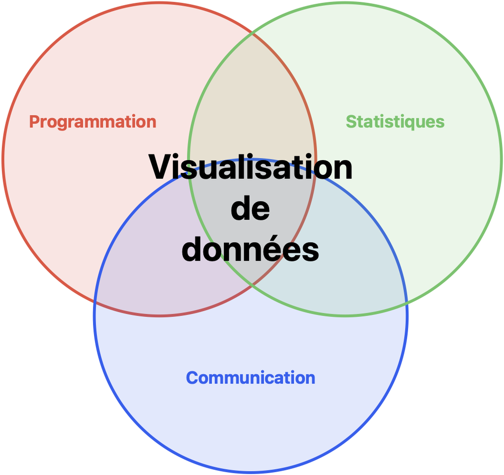

*inspiré du schéma du cours [SDS 375](https://wilkelab.org/SDS375/) de Claus O. Wilke*

## Les statistiques

## Une idée

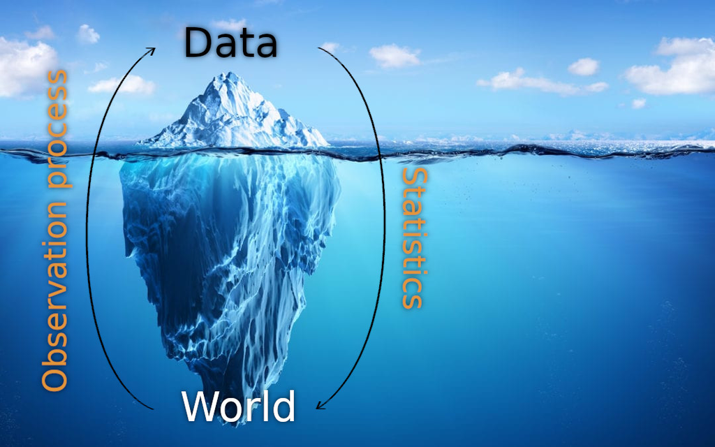

image empruntée d’un cours de F. Muñoz.

## But du jeu

*Étudier les propriétés d’une* **population**  
\(~\)

1. L’ensemble des français
2. L’ensemble des foyers fiscaux
3. L’ensemble des arbres d’une forêt
4. L’ensemble des surfaces cultivables

*à partir d’un* **échantillon**.  
\(~\)

1. Sondage auprès des français
2. Contrôles fiscaux
3. Quelques arbres pris au hasard
4. Sondage auprès des agriculteurs

## Définitions

**Individu**: *unités statistiques soumises à l’étude*

\(\hookrightarrow\) un arbre

**Population**: *ensemble de tous les individus concernés par l’étude*

\(\hookrightarrow\) la forêt de Fontainebleau

**Échantillon**: *sous-ensemble de la population*

\(\hookrightarrow\) arbres abattus par les gardes champêtres

**Taille** de l’échantillon: *nombre d’individus dans l’échantillon*

\(\hookrightarrow\) nombre d’arbres abattus par les gardes champêtres

## Exemples

**Individu**: un français  
**Population**: tous les français  
**Échantillon**: sondage IPSOS  
**Taille**: 10000

**Individu**: un foyer fiscal  
**Population**: tous les foyers fiscaux  
**Échantillon**: les foyers fiscaux contrôlés  
**Taille**: 1000

**Individu**: une parcelle agricole  
**Population**: toutes surfaces cultivables d’Occitanie  
**Échantillon**: mon potager  
**Taille**: 1

## Problématique

\(\rightarrow\) on pose une **question** sur la population.

\(\rightarrow\) on répond en mesurant une **variable** sur les individus de l’échantillon.

## Exemples

Combien d’enfants ont les français ?

**Individu**: un français  
**Population**: tous les français  
**Échantillon**: sondage IPSOS  
**Taille**: 10000  
**Variable**: nombre d’enfants

Combien payent les français en impôts sur le revenu ?

**Individu**: un foyer fiscal  
**Population**: tous les foyers fiscaux  
**Échantillon**: les foyers fiscaux contrôlés  
**Taille**: 1000  
**Variable**: somme versée à l’administration

## Exemples

Les arbres de la forêt de Fontainebleau sont-ils en bonne santé ?

**Individu**: un arbre  
**Population**: la forêt de Fontainebleau  
**Échantillon**: arbres abattus  
**Taille**: 100  
**Variable**: santé de l’arbre

Quelle est l’orientation des parcelles agricoles ?

**Individu**: une parcelle agricole  
**Population**: toutes surfaces cultivables d’Occitanie  
**Échantillon**: mon potager  
**Taille**: 1  
**Variable**: orientation

## Variable et modalités

**Variable**: caractéristique mesurée

**Modalités**: valeurs possibles de la variable

## Exemples

**Variable**: nombre d’enfants  
**Modalités**: un chiffre positif

**Variable**: somme versée à l’administration  
**Valeurs**: un nombre positif

**Variable**: santé de l’arbre  
**Modalités**: mauvaise, moyenne, bonne, excellente

**Variable**: orientation  
**Modalités**: Nord, Sud, Est, Ouest

## Variable et modalités

**Variable**: caractéristique mesurée

**Modalités**: valeurs possibles de la variable

**Attention**: les modalités doivent être:

- *incompatibles* la réponse d’un individu ne peut appartenir à plus d’une modalité;
- *exhaustives* : toutes les situations possibles doivent être prévues ;
- *sans ambiguité* : éviter des erreurs de classement.

## Variables qualitatives et quantitatives

- **Qualitative** les modalités sont des **noms**.
  - **ordinale**: échelle entre les modalités
  - **nominales**: pas de relation d’ordre entre les modalités.

\(~\)  
\(~\)

- **Quantitative** les modalités sont des **nombres**.
  - **discrète**: nombres “isolés” (chiffres entiers)
  - **continus**: valeurs réelles (nombres à virgules)

## Exemples

**Variable**: nombre d’enfants; \(\qquad\) **Modalités**: un chiffre

- \(\to\) quantitative, discrète

**Variable**: somme versée à l’administration  
**Valeurs**: un nombre positif

- \(\to\) quantitative, continue

**Variable**: santé de l’arbre  
**Modalités**: mauvaise, moyenne, bonne, excellente

- \(\to\) qualitative, ordinale

**Variable**: orientation; \(\qquad\) **Modalités**: Nord, Sud, Est, Ouest

- \(\to\) qualitative, nominale

## Démarche statistique

1 - On se pose une question sur une population.

*Quel âge ont les montpelliérains ?*

2 - On définit une variable à mesurer.

*âge (variable quantitative continue)*

3 - On choisi un échantillon.

*sondage auprès de 1000 montpelliérains tirés au hasard*

4 - On mesure la variable sur les individus de l’échantillon.

*“Bonjour Monsieur, c’est pour un sondage, quel âge avez-vous ?”*

5 - Et après ?

## `R`

## Rappel

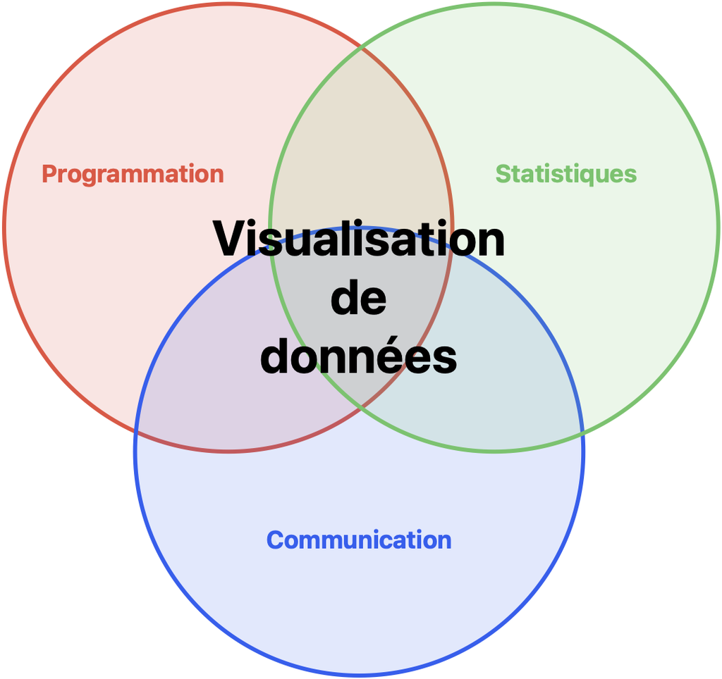

`R` est la solution

## `R`-Studio

C’est une interface :

- avec son propre langage de programmation (fichier `.R`).
- optimisée pour la statistique (la plupart des notions sont codées dans des librairies).
- permet de produire des figures de qualité.
- permet de produire des rapports pour la transmission des résultats (`.Rmd`…)

## `R`-Studio

Ce transparent est fait à l’aide de `R`-studio.

## Rudiments de `R`

## Structure

L’interface est structurée ainsi :

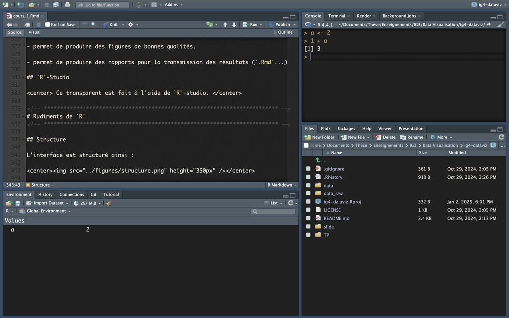

## Opérations

- Les opérations classiques : `+`, `-`, `*` et `/` (`**` ou `^` pour la puissance).
- Opérateur sur les booléens :

```r
# ou
TRUE || FALSE
```

```
## [1] TRUE
```

```r
# et
TRUE && FALSE
```

```
## [1] FALSE
```

## Déclaration de variable

Il y a deux manières de déclarer une variable :

```r
a <- 2
# ou
b = "deux"

print(c(a, b))
```

```
## [1] "2"    "deux"
```

## Création de vecteur simples

Il faut utiliser la lettre `c`:

```r
a <- c(1, 2, 3, 4)
print(a)
```

```
## [1] 1 2 3 4
```

```r
# L'indexation commence à 1 et se fait avec des crochets.
print(a[1])
```

```
## [1] 1
```

## Boucles classiques

- *if* :

```r
if(condition){
  ...
}
```

- *for* :

```r
for(i in liste_index){
  ...
}
```

- *while* :

```r
while(condition){
  ...
}
```

## Fonctions de bases

Il y a aussi des fonctions “classiques” utiles en statistiques :

- `mean()` calcule la moyenne d’un vecteur.
- `var()` calcule la variance d’un vecteur.
- `1:n` crée un vecteur de allant de \(1\) à \(n\) (utile pour les boucles `for`).

et pleins d’autres…

## Manipulation et aberrations

## C’est si facile pourtant…

Pourquoi faire ce cours ? C’est facile de faire un beau graphique…

Non pas vraiment…

## Vaccins

[figure not shown]

## Grèves SNCF

[figure not shown]

Source : [Libération](https://www.liberation.fr/checknews/2018/04/27/est-ce-que-bfmtv-a-vraiment-affiche-un-graphique-a-camembert-trompeur-sur-le-soutien-a-la-greve-des-_1653615/)

## Sondages

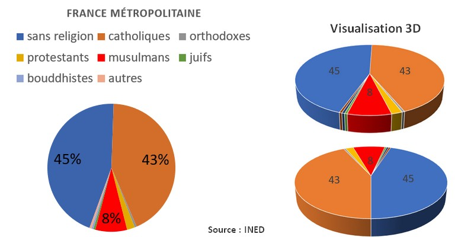

\(~\)

[Source](https://quoidansmonassiette.fr/tromper-avec-graphiques-representations-visuelles-pour-manipuler-opinion-publique-guide/)

## Grèves SNCF

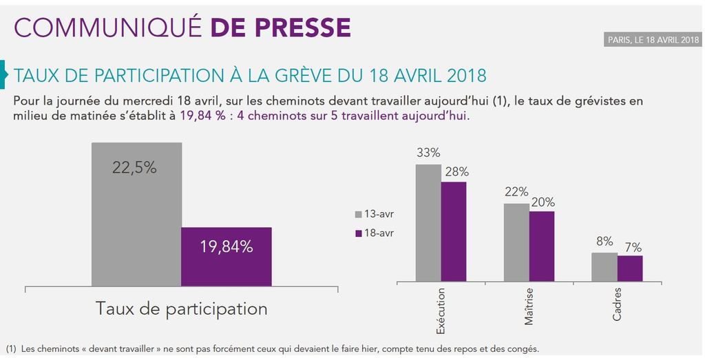

Source : [Libération](https://www.liberation.fr/checknews/2018/04/27/est-ce-que-bfmtv-a-vraiment-affiche-un-graphique-a-camembert-trompeur-sur-le-soutien-a-la-greve-des-_1653615/)

## Places en médecine

[figure not shown]

Source : Notre ancienne ministre

## Economic Growth

[figure not shown]

Source : Ce bon vieux Donald